# Titanic

Arun kr. Khattri

3 March 2018

# Introduction

## all required libraries

```r
library(tidyverse)
library(ggthemes)
library(Amelia)
library(ggthemes)
library(caTools)
library(data.table)
library(corrplot)
library(corrgram)
library(glmnet)
library(xgboost)
```

## Loading the data sets

```r
train.file <- "./train.csv"
test.file <- "./test.csv"
test <- read_csv(test.file)
train <- read_csv((train.file))
```

### Check the dimensions

```r
print(paste0(c("train Rows: ", "train Cols: "), dim(train)))
```

```
## [1] "train Rows: 891" "train Cols: 12"
```

```r
print(paste0(c("test Rows: ", "test Cols: "), dim(test)))
```

```
## [1] "test Rows: 418" "test Cols: 11"
```

### Merge data set

let’s combine the train and test data first, to combine, column lengths must be same

```r
train$set <- "train"
test$set <- "test"
test$Survived <- NA
df <- rbind(train, test)
glimpse(df)
```

```
## Observations: 1,309
## Variables: 13
## $ PassengerId <int> 1, 2, 3, 4, 5, 6, 7, 8, 9, 10, 11, 12, 13, 14, 15,...
## $ Survived    <int> 0, 1, 1, 1, 0, 0, 0, 0, 1, 1, 1, 1, 0, 0, 0, 1, 0,...
## $ Pclass      <int> 3, 1, 3, 1, 3, 3, 1, 3, 3, 2, 3, 1, 3, 3, 3, 2, 3,...
## $ Name        <chr> "Braund, Mr. Owen Harris", "Cumings, Mrs. John Bra...
## $ Sex         <chr> "male", "female", "female", "female", "male", "mal...
## $ Age         <dbl> 22, 38, 26, 35, 35, NA, 54, 2, 27, 14, 4, 58, 20, ...
## $ SibSp       <int> 1, 1, 0, 1, 0, 0, 0, 3, 0, 1, 1, 0, 0, 1, 0, 0, 4,...
## $ Parch       <int> 0, 0, 0, 0, 0, 0, 0, 1, 2, 0, 1, 0, 0, 5, 0, 0, 1,...
## $ Ticket      <chr> "A/5 21171", "PC 17599", "STON/O2. 3101282", "1138...
## $ Fare        <dbl> 7.2500, 71.2833, 7.9250, 53.1000, 8.0500, 8.4583, ...
## $ Cabin       <chr> NA, "C85", NA, "C123", NA, NA, "E46", NA, NA, NA, ...
## $ Embarked    <chr> "S", "C", "S", "S", "S", "Q", "S", "S", "S", "C", ...
## $ set         <chr> "train", "train", "train", "train", "train", "trai...
```

# Exploratory Data Analysis & Feature Engineering

## Unique values per column

```r
unq_val <- df %>%
  summarise_at(colnames(df), funs(n_distinct))

unq_val <- gather(unq_val, key = "feature",
                         value = "Unq.Val")
unq_val
```

```
## # A tibble: 13 x 2
##        feature Unq.Val
##          <chr>   <int>
##  1 PassengerId    1309
##  2    Survived       3
##  3      Pclass       3
##  4        Name    1307
##  5         Sex       2
##  6         Age      99
##  7       SibSp       7
##  8       Parch       8
##  9      Ticket     929
## 10        Fare     282
## 11       Cabin     187
## 12    Embarked       4
## 13         set       2
```

Plotting it

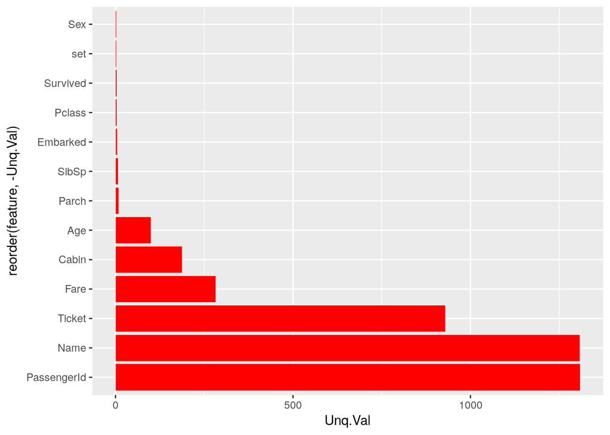

```r
unq_val %>%
  ggplot(aes(x=reorder(feature, -Unq.Val), y=Unq.Val)) +
  geom_bar(stat = 'identity', fill='red') +
  coord_flip()
```

## Check for missing values…

### using “Amelia”

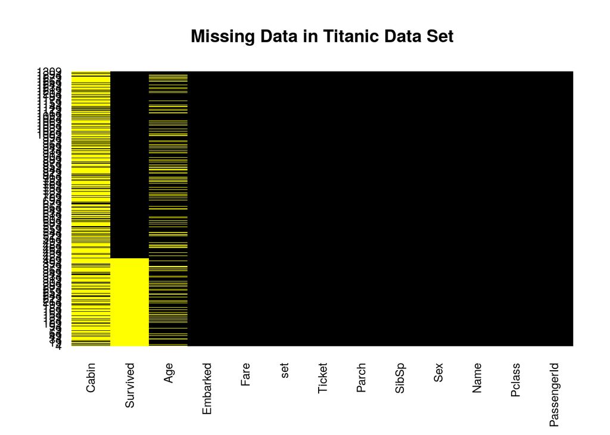

```r
missmap(df, legend = FALSE, col = c("yellow", "black"),
        main = "Missing Data in Titanic Data Set")
```

gives a fair idea where data is missing. In case of Survived its test data which was combined, Cabin and Age has missing data in train as well as test data, Embarked has missing data in train data set.

### using dplyr…

```r
missing.values <- df %>%
  summarise_all(funs(sum(is.na(.)) / n()))

missing.values <- gather(missing.values, key = "feature",
                         value = "missing.pct")

missing.values
```

```
## # A tibble: 13 x 2
##        feature  missing.pct
##          <chr>        <dbl>
##  1 PassengerId 0.0000000000
##  2    Survived 0.3193277311
##  3      Pclass 0.0000000000
##  4        Name 0.0000000000
##  5         Sex 0.0000000000
##  6         Age 0.2009167303
##  7       SibSp 0.0000000000
##  8       Parch 0.0000000000
##  9      Ticket 0.0000000000
## 10        Fare 0.0007639419
## 11       Cabin 0.7746371276
## 12    Embarked 0.0015278839
## 13         set 0.0000000000
```

Plotting the above info…

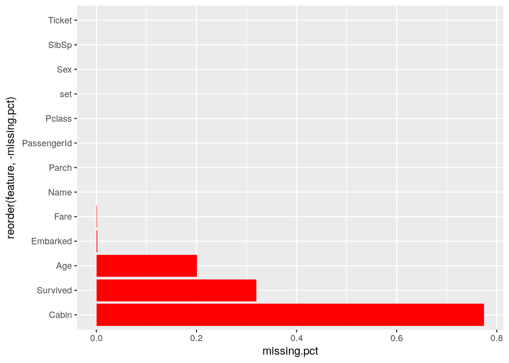

```r
missing.values %>%
  ggplot(aes(x=reorder(feature, -missing.pct), y=missing.pct)) +
  geom_bar(stat = 'identity', fill='red') +
  coord_flip()
```

# Survivals

using train data…

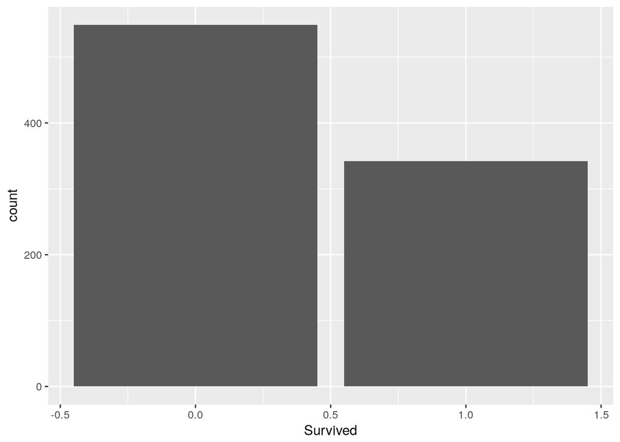

```r
df %>%
  filter(set == "train") %>%
  ggplot(aes(Survived)) +
  geom_bar()
```

## Survival Rate…

```r
survival.summary <- df %>%
  filter(set == "train") %>%
  select(PassengerId, Survived) %>%
  group_by(Survived) %>%
  summarise(n=n()) %>%
  mutate(perCent = n / sum(n))

survival.summary
```

```
## # A tibble: 2 x 3
##   Survived     n   perCent
##      <int> <int>     <dbl>
## 1        0   549 0.6161616
## 2        1   342 0.3838384
```

```r
surv.rate <- survival.summary$perCent[survival.summary$Survived == 1]
surv.rate
```

```
## [1] 0.3838384
```

## Survival by Pclass…

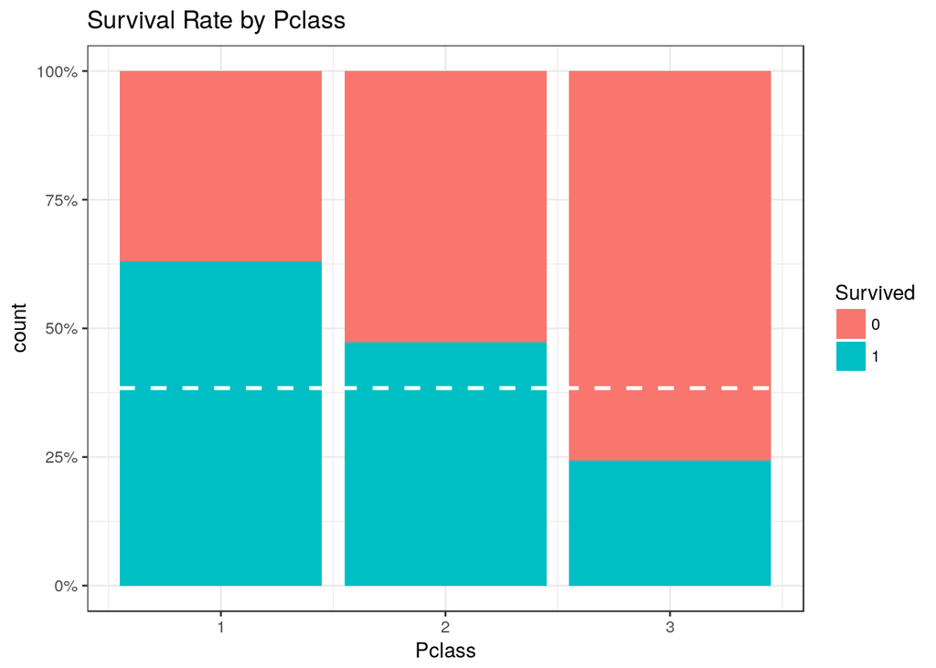

```r
df %>%
  filter(set == "train") %>%
  ggplot(aes(Pclass, fill=Survived)) +
  geom_bar(aes(fill=factor(Survived)), position = "fill") +
  scale_y_continuous(labels = scales::percent) +
  labs(title="Survival Rate by Pclass",
       xlab = "Pclass",
       ylab = "Survival Rate") +
  geom_hline(yintercept = surv.rate, col="white", lty=2, size=1) +
  theme_bw()
```

travelling First class has its own advantages…

## Survival by Sex…

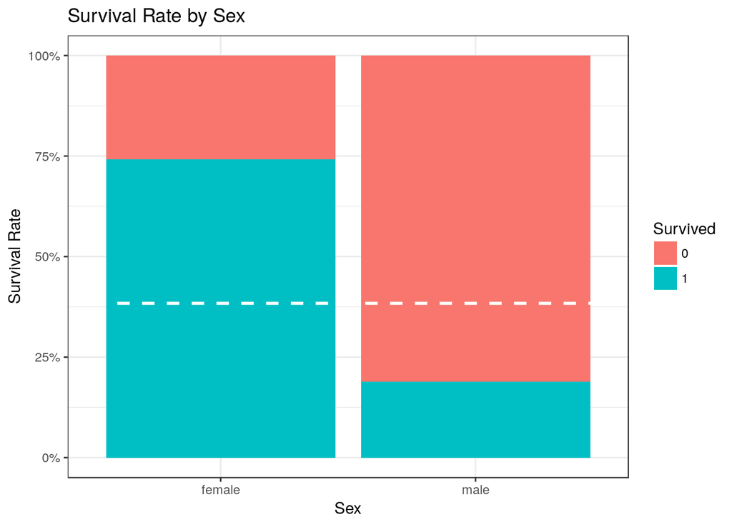

```r
df %>%
  filter(set == "train") %>%
  ggplot(aes(Sex, fill=Survived)) +
  geom_bar(aes(fill=factor(Survived)), position = "fill") +
  scale_y_continuous(labels = scales::percent) +
  labs(title="Survival Rate by Sex",
       x = "Sex",
       y = "Survival Rate") +
  geom_hline(yintercept = surv.rate, col="white", lty=2, size=1) +
  theme_bw()
```

Almost 75% of female’s survived…

## Survival by Age…

Aroun 20% of the data under this head is missing, let’s first fill them by taking averages of the class they are travelling in and imputing age accordingly…

### function for imputing Age…

```r
impute_age <- function(age, pclass) {
  out <- age
  for (i in 1:length(age)) {
    if (is.na(age[i])) {
      if (pclass[i] == 1) {
        avg_age <- mean(df[which(df$Pclass == 1),]$Age, na.rm = TRUE)
        out[i] <- avg_age
      }else if (pclass[i] == 2) {
        avg_age <- mean(df[which(df$Pclass == 2),]$Age, na.rm = TRUE)
        out[i] <- avg_age
      }else{
        avg_age <- mean(df[which(df$Pclass == 3),]$Age, na.rm = TRUE)
        out[i] <- avg_age
      }
    }else{
      out[i] <- age[i]
    }
  }
  return(out)
}
```

### Imputing the age.

```r
fixed.age <- impute_age(df$Age, df$Pclass)
df$Age <- fixed.age
```

### Survival rate by Age

Now plotting the survival rate by age…

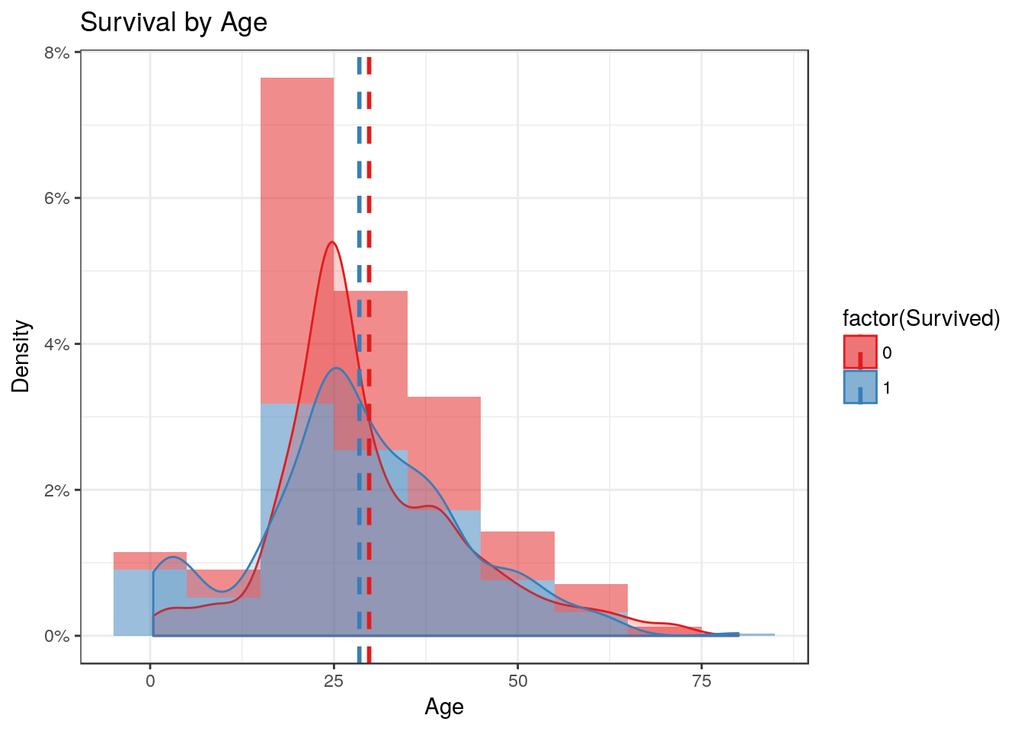

```r
tbl.age <- df %>%
  filter(set == "train") %>%
  select(Age, Survived) %>%
  group_by(Survived) %>%
  summarise(mean.age = mean(Age, na.rm = TRUE))

df %>%
  filter(set == "train") %>%
  ggplot(aes(Age, fill=factor(Survived))) +
  geom_histogram(aes(y=..density..), binwidth = 10, alpha=0.5) +
  geom_density(aes(color = factor(Survived)), alpha = 0.2) +
  geom_vline(data = tbl.age,
             aes(xintercept=mean.age, color=factor(Survived)), lty=2, size=1) +
  scale_fill_brewer(palette = "Set1") +
  scale_color_brewer(palette = "Set1") +
  scale_y_continuous(labels = scales::percent) +
  labs(title = "Survival by Age",
       x = "Age",
       y = "Density") +
  theme_bw()
```

### Survival Rate by Age Group

let’s define the age group and see the survival rate by age-group

```r
df <- df %>%
  mutate(AgeGroup = case_when(Age < 2 ~ "infants",
                              Age >= 2 & Age < 12 ~ "children",
                              Age >= 12 & Age < 18 ~ "teenagers",
                              Age >= 18 & Age < 25 ~ "youngAdults",
                              Age >= 25 & Age < 40 ~ "adults",
                              Age >= 40 & Age < 60 ~ "middleAge",
                              Age >= 60 ~ "old"))
df$AgeGroup <- as.factor(df$AgeGroup)
glimpse(df)
```

```
## Observations: 1,309
## Variables: 14
## $ PassengerId <int> 1, 2, 3, 4, 5, 6, 7, 8, 9, 10, 11, 12, 13, 14, 15,...
## $ Survived    <int> 0, 1, 1, 1, 0, 0, 0, 0, 1, 1, 1, 1, 0, 0, 0, 1, 0,...
## $ Pclass      <int> 3, 1, 3, 1, 3, 3, 1, 3, 3, 2, 3, 1, 3, 3, 3, 2, 3,...
## $ Name        <chr> "Braund, Mr. Owen Harris", "Cumings, Mrs. John Bra...
## $ Sex         <chr> "male", "female", "female", "female", "male", "mal...
## $ Age         <dbl> 22.00000, 38.00000, 26.00000, 35.00000, 35.00000, ...
## $ SibSp       <int> 1, 1, 0, 1, 0, 0, 0, 3, 0, 1, 1, 0, 0, 1, 0, 0, 4,...
## $ Parch       <int> 0, 0, 0, 0, 0, 0, 0, 1, 2, 0, 1, 0, 0, 5, 0, 0, 1,...
## $ Ticket      <chr> "A/5 21171", "PC 17599", "STON/O2. 3101282", "1138...
## $ Fare        <dbl> 7.2500, 71.2833, 7.9250, 53.1000, 8.0500, 8.4583, ...
## $ Cabin       <chr> NA, "C85", NA, "C123", NA, NA, "E46", NA, NA, NA, ...
## $ Embarked    <chr> "S", "C", "S", "S", "S", "Q", "S", "S", "S", "C", ...
## $ set         <chr> "train", "train", "train", "train", "train", "trai...
## $ AgeGroup    <fctr> youngAdults, adults, adults, adults, adults, youn...
```

Okay, Let’s change some of them to appropriate data type

```r
df$Survived <- factor(df$Survived)
df$Pclass <- factor(df$Pclass)
glimpse(df)
```

```
## Observations: 1,309
## Variables: 14
## $ PassengerId <int> 1, 2, 3, 4, 5, 6, 7, 8, 9, 10, 11, 12, 13, 14, 15,...
## $ Survived    <fctr> 0, 1, 1, 1, 0, 0, 0, 0, 1, 1, 1, 1, 0, 0, 0, 1, 0...
## $ Pclass      <fctr> 3, 1, 3, 1, 3, 3, 1, 3, 3, 2, 3, 1, 3, 3, 3, 2, 3...
## $ Name        <chr> "Braund, Mr. Owen Harris", "Cumings, Mrs. John Bra...
## $ Sex         <chr> "male", "female", "female", "female", "male", "mal...
## $ Age         <dbl> 22.00000, 38.00000, 26.00000, 35.00000, 35.00000, ...
## $ SibSp       <int> 1, 1, 0, 1, 0, 0, 0, 3, 0, 1, 1, 0, 0, 1, 0, 0, 4,...
## $ Parch       <int> 0, 0, 0, 0, 0, 0, 0, 1, 2, 0, 1, 0, 0, 5, 0, 0, 1,...
## $ Ticket      <chr> "A/5 21171", "PC 17599", "STON/O2. 3101282", "1138...
## $ Fare        <dbl> 7.2500, 71.2833, 7.9250, 53.1000, 8.0500, 8.4583, ...
## $ Cabin       <chr> NA, "C85", NA, "C123", NA, NA, "E46", NA, NA, NA, ...
## $ Embarked    <chr> "S", "C", "S", "S", "S", "Q", "S", "S", "S", "C", ...
## $ set         <chr> "train", "train", "train", "train", "train", "trai...
## $ AgeGroup    <fctr> youngAdults, adults, adults, adults, adults, youn...
```

Now looking at survival rate by age groups…

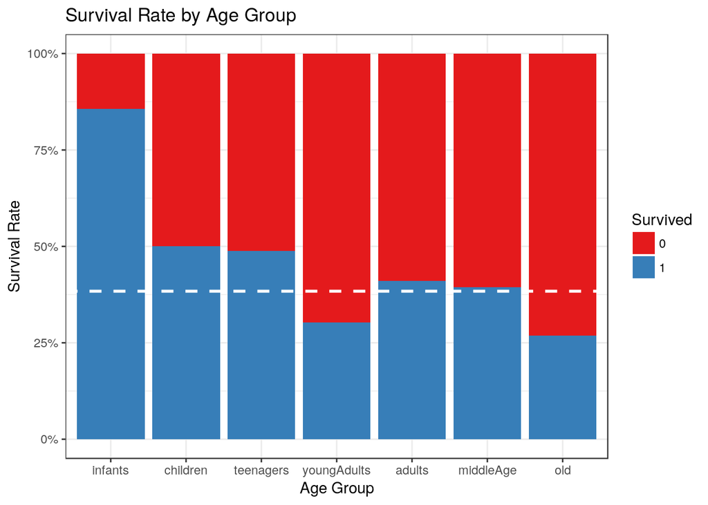

```r
age.group <- c("infants", "children", "teenagers", "youngAdults",
               "adults", "middleAge", "old")

df %>%
  filter(set == "train") %>%
  ggplot(aes(AgeGroup, fill=Survived))+
  geom_bar(position = "fill") +
  scale_fill_brewer(palette = "Set1") +
  scale_y_continuous(labels = scales::percent) +
  scale_x_discrete(limits=age.group) +
  geom_hline(yintercept = surv.rate, col="white", lty=2, size=1) +
  labs(title = "Survival Rate by Age Group",
       x = "Age Group",
       y = "Survival Rate") +
  theme_bw()
```

## Survival by Title

Grouping the passenger’s on their title

Extracting the title from the name and storing them under column “title”…

```r
strp.title <- function(x){
  splt <- strsplit(x, split = "[,.]")
  titl <- splt[[1]][2]
  return(sub(" ", "", titl))
}

df$title <- sapply(df$Name, strp.title)
glimpse(df)
```

```
## Observations: 1,309
## Variables: 15
## $ PassengerId <int> 1, 2, 3, 4, 5, 6, 7, 8, 9, 10, 11, 12, 13, 14, 15,...
## $ Survived    <fctr> 0, 1, 1, 1, 0, 0, 0, 0, 1, 1, 1, 1, 0, 0, 0, 1, 0...
## $ Pclass      <fctr> 3, 1, 3, 1, 3, 3, 1, 3, 3, 2, 3, 1, 3, 3, 3, 2, 3...
## $ Name        <chr> "Braund, Mr. Owen Harris", "Cumings, Mrs. John Bra...
## $ Sex         <chr> "male", "female", "female", "female", "male", "mal...
## $ Age         <dbl> 22.00000, 38.00000, 26.00000, 35.00000, 35.00000, ...
## $ SibSp       <int> 1, 1, 0, 1, 0, 0, 0, 3, 0, 1, 1, 0, 0, 1, 0, 0, 4,...
## $ Parch       <int> 0, 0, 0, 0, 0, 0, 0, 1, 2, 0, 1, 0, 0, 5, 0, 0, 1,...
## $ Ticket      <chr> "A/5 21171", "PC 17599", "STON/O2. 3101282", "1138...
## $ Fare        <dbl> 7.2500, 71.2833, 7.9250, 53.1000, 8.0500, 8.4583, ...
## $ Cabin       <chr> NA, "C85", NA, "C123", NA, NA, "E46", NA, NA, NA, ...
## $ Embarked    <chr> "S", "C", "S", "S", "S", "Q", "S", "S", "S", "C", ...
## $ set         <chr> "train", "train", "train", "train", "train", "trai...
## $ AgeGroup    <fctr> youngAdults, adults, adults, adults, adults, youn...
## $ title       <chr> "Mr", "Mrs", "Miss", "Mrs", "Mr", "Mr", "Mr", "Mas...
```

All the unique titles and their counts

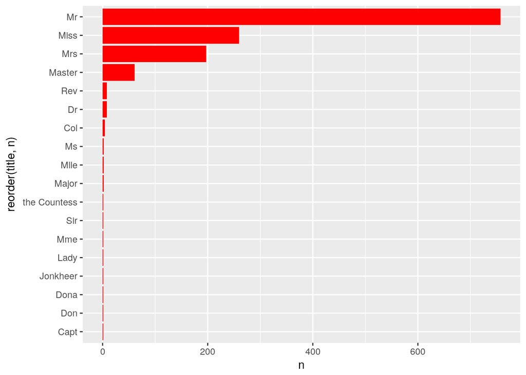

```r
tbl_title <- df %>%
  select(PassengerId, title) %>%
  group_by(title) %>%
  summarise(n = n())
tbl_title %>%
  ggplot(aes(x=reorder(title, n), y = n)) +
  geom_bar(stat = "identity", fill='red') +
  coord_flip()
```

Grouping the titles…

```r
noble <- c("Don", "Dona", "Jonkheer", "Lady", "Dr", "Rev", "Sir", "the Countess")
Ms <- c("Miss", "Mlle", "Ms")
Mrs <- c("Mme", "Mrs")
armyOfficer <- c("Capt", "Col", "Major")

df <- df %>%
  mutate(ttl.group = case_when(title %in% noble ~ "noble",
                               title %in% Ms ~ "Ms",
                               title %in% Mrs ~ "Mrs",
                               title %in% armyOfficer ~ "armyOfficer",
                               title == "Master" ~ "Master",
                               title == "Mr" ~ "Mr"))
glimpse(df)
```

```
## Observations: 1,309
## Variables: 16
## $ PassengerId <int> 1, 2, 3, 4, 5, 6, 7, 8, 9, 10, 11, 12, 13, 14, 15,...
## $ Survived    <fctr> 0, 1, 1, 1, 0, 0, 0, 0, 1, 1, 1, 1, 0, 0, 0, 1, 0...
## $ Pclass      <fctr> 3, 1, 3, 1, 3, 3, 1, 3, 3, 2, 3, 1, 3, 3, 3, 2, 3...
## $ Name        <chr> "Braund, Mr. Owen Harris", "Cumings, Mrs. John Bra...
## $ Sex         <chr> "male", "female", "female", "female", "male", "mal...
## $ Age         <dbl> 22.00000, 38.00000, 26.00000, 35.00000, 35.00000, ...
## $ SibSp       <int> 1, 1, 0, 1, 0, 0, 0, 3, 0, 1, 1, 0, 0, 1, 0, 0, 4,...
## $ Parch       <int> 0, 0, 0, 0, 0, 0, 0, 1, 2, 0, 1, 0, 0, 5, 0, 0, 1,...
## $ Ticket      <chr> "A/5 21171", "PC 17599", "STON/O2. 3101282", "1138...
## $ Fare        <dbl> 7.2500, 71.2833, 7.9250, 53.1000, 8.0500, 8.4583, ...
## $ Cabin       <chr> NA, "C85", NA, "C123", NA, NA, "E46", NA, NA, NA, ...
## $ Embarked    <chr> "S", "C", "S", "S", "S", "Q", "S", "S", "S", "C", ...
## $ set         <chr> "train", "train", "train", "train", "train", "trai...
## $ AgeGroup    <fctr> youngAdults, adults, adults, adults, adults, youn...
## $ title       <chr> "Mr", "Mrs", "Miss", "Mrs", "Mr", "Mr", "Mr", "Mas...
## $ ttl.group   <chr> "Mr", "Mrs", "Ms", "Mrs", "Mr", "Mr", "Mr", "Maste...
```

### Survival Rate by title group

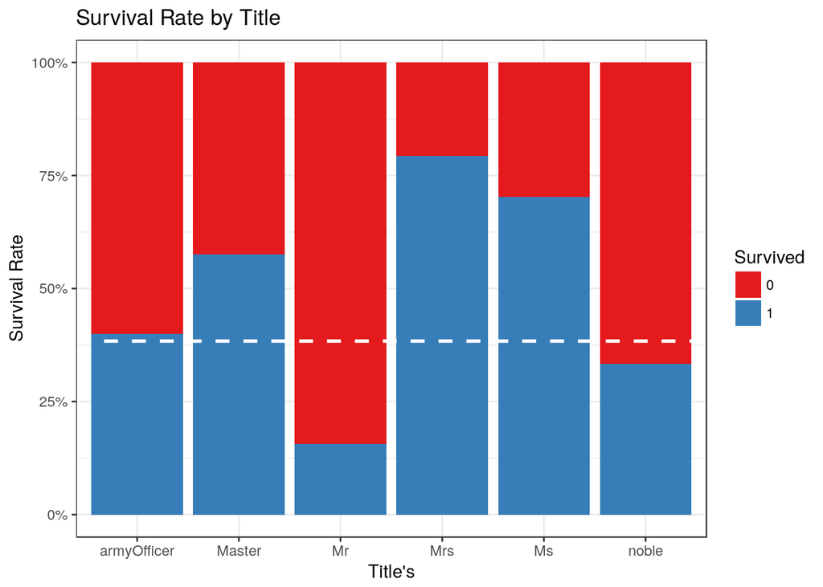

```r
df %>%
  filter(set == "train") %>%
  ggplot(aes(ttl.group, fill=Survived))+
  geom_bar(position = "fill") +
  scale_fill_brewer(palette = "Set1") +
  scale_y_continuous(labels = scales::percent) +
  geom_hline(yintercept = surv.rate, col="white", lty=2, size=1) +
  labs(title = "Survival Rate by Title",
       x = "Title's",
       y = "Survival Rate") +
  theme_bw()
```

## Survival by Family Groups

```r
df <- df %>%
  mutate(familySize = SibSp + Parch + 1,
         familyGrp = case_when(familySize == 1 ~ "Single",
                               familySize >= 2 & familySize < 5 ~ "Small",
                               familySize >= 5 ~ "Big"),
         familyGrp = as.factor(familyGrp))
glimpse(df)
```

```
## Observations: 1,309
## Variables: 18
## $ PassengerId <int> 1, 2, 3, 4, 5, 6, 7, 8, 9, 10, 11, 12, 13, 14, 15,...
## $ Survived    <fctr> 0, 1, 1, 1, 0, 0, 0, 0, 1, 1, 1, 1, 0, 0, 0, 1, 0...
## $ Pclass      <fctr> 3, 1, 3, 1, 3, 3, 1, 3, 3, 2, 3, 1, 3, 3, 3, 2, 3...
## $ Name        <chr> "Braund, Mr. Owen Harris", "Cumings, Mrs. John Bra...
## $ Sex         <chr> "male", "female", "female", "female", "male", "mal...
## $ Age         <dbl> 22.00000, 38.00000, 26.00000, 35.00000, 35.00000, ...
## $ SibSp       <int> 1, 1, 0, 1, 0, 0, 0, 3, 0, 1, 1, 0, 0, 1, 0, 0, 4,...
## $ Parch       <int> 0, 0, 0, 0, 0, 0, 0, 1, 2, 0, 1, 0, 0, 5, 0, 0, 1,...
## $ Ticket      <chr> "A/5 21171", "PC 17599", "STON/O2. 3101282", "1138...
## $ Fare        <dbl> 7.2500, 71.2833, 7.9250, 53.1000, 8.0500, 8.4583, ...
## $ Cabin       <chr> NA, "C85", NA, "C123", NA, NA, "E46", NA, NA, NA, ...
## $ Embarked    <chr> "S", "C", "S", "S", "S", "Q", "S", "S", "S", "C", ...
## $ set         <chr> "train", "train", "train", "train", "train", "trai...
## $ AgeGroup    <fctr> youngAdults, adults, adults, adults, adults, youn...
## $ title       <chr> "Mr", "Mrs", "Miss", "Mrs", "Mr", "Mr", "Mr", "Mas...
## $ ttl.group   <chr> "Mr", "Mrs", "Ms", "Mrs", "Mr", "Mr", "Mr", "Maste...
## $ familySize  <dbl> 2, 2, 1, 2, 1, 1, 1, 5, 3, 2, 3, 1, 1, 7, 1, 1, 6,...
## $ familyGrp   <fctr> Small, Small, Single, Small, Single, Single, Sing...
```

Survival rate by Family

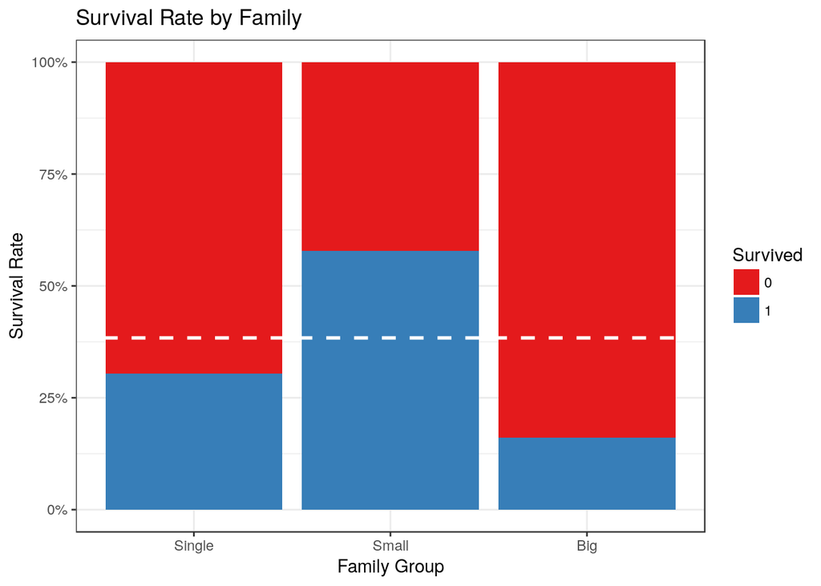

```r
fam.grp <- c("Single", "Small", "Big")
df %>%
  filter(set == "train") %>%
  ggplot(aes(familyGrp, fill=Survived))+
  geom_bar(position = "fill") +
  scale_fill_brewer(palette = "Set1") +
  scale_y_continuous(labels = scales::percent) +
  scale_x_discrete(limits=fam.grp)+
  geom_hline(yintercept = surv.rate, col="white", lty=2, size=1) +
  labs(title = "Survival Rate by Family",
       x = "Family Group",
       y = "Survival Rate") +
  theme_bw()
```

## Survival by port of embark

using the most common port to replace the NA

```r
df$Embarked <- replace(df$Embarked, which(is.na(df$Embarked)), "S")
df$Embarked <- as.factor(df$Embarked)
levels(df$Embarked)
```

```
## [1] "C" "Q" "S"
```

Survival Rate by Embarked

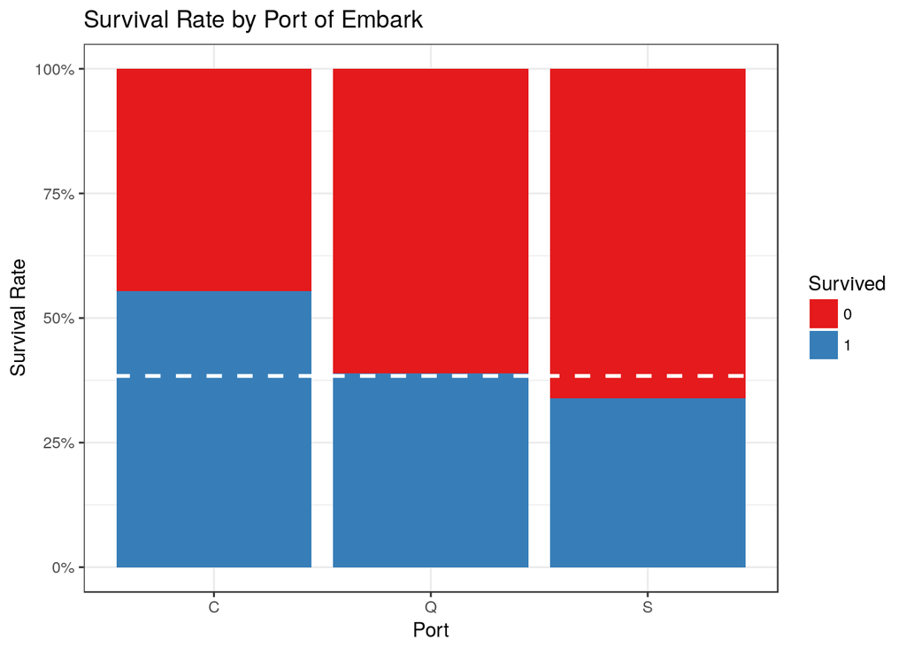

```r
df %>%
  filter(set == "train") %>%
  ggplot(aes(Embarked, fill=Survived))+
  geom_bar(position = "fill") +
  scale_fill_brewer(palette = "Set1") +
  scale_y_continuous(labels = scales::percent) +
  geom_hline(yintercept = surv.rate, col="white", lty=2, size=1) +
  labs(title = "Survival Rate by Port of Embark",
       x = "Port",
       y = "Survival Rate") +
  theme_bw()
```

# Setting the data for final show

Finally setting the correct data types to left overs…

```r
df <- df %>%
  mutate(Sex = as.factor(Sex),
         SibSp = as.factor(SibSp),
         Parch = as.factor(Parch),
         title = as.factor(title),
         ttl.group = as.factor(ttl.group))
str(df)
```

```
## Classes 'tbl_df', 'tbl' and 'data.frame':    1309 obs. of  18 variables:
##  $ PassengerId: int  1 2 3 4 5 6 7 8 9 10 ...
##  $ Survived   : Factor w/ 2 levels "0","1": 1 2 2 2 1 1 1 1 2 2 ...
##  $ Pclass     : Factor w/ 3 levels "1","2","3": 3 1 3 1 3 3 1 3 3 2 ...
##  $ Name       : chr  "Braund, Mr. Owen Harris" "Cumings, Mrs. John Bradley (Florence Briggs Thayer)" "Heikkinen, Miss. Laina" "Futrelle, Mrs. Jacques Heath (Lily May Peel)" ...
##  $ Sex        : Factor w/ 2 levels "female","male": 2 1 1 1 2 2 2 2 1 1 ...
##  $ Age        : num  22 38 26 35 35 ...
##  $ SibSp      : Factor w/ 7 levels "0","1","2","3",..: 2 2 1 2 1 1 1 4 1 2 ...
##  $ Parch      : Factor w/ 8 levels "0","1","2","3",..: 1 1 1 1 1 1 1 2 3 1 ...
##  $ Ticket     : chr  "A/5 21171" "PC 17599" "STON/O2. 3101282" "113803" ...
##  $ Fare       : num  7.25 71.28 7.92 53.1 8.05 ...
##  $ Cabin      : chr  NA "C85" NA "C123" ...
##  $ Embarked   : Factor w/ 3 levels "C","Q","S": 3 1 3 3 3 2 3 3 3 1 ...
##  $ set        : chr  "train" "train" "train" "train" ...
##  $ AgeGroup   : Factor w/ 7 levels "adults","children",..: 7 1 1 1 1 7 4 2 1 6 ...
##  $ title      : Factor w/ 18 levels "Capt","Col","Don",..: 13 14 10 14 13 13 13 9 14 14 ...
##  $ ttl.group  : Factor w/ 6 levels "armyOfficer",..: 3 4 5 4 3 3 3 2 4 4 ...
##  $ familySize : num  2 2 1 2 1 1 1 5 3 2 ...
##  $ familyGrp  : Factor w/ 3 levels "Big","Single",..: 3 3 2 3 2 2 2 1 3 3 ...
```

Let’s do the final recheck of the data and keep it in proper data type

```r
df <- df %>%
  mutate(familySize = as.factor(familySize))
str(df)
```

```
## Classes 'tbl_df', 'tbl' and 'data.frame':    1309 obs. of  18 variables:
##  $ PassengerId: int  1 2 3 4 5 6 7 8 9 10 ...
##  $ Survived   : Factor w/ 2 levels "0","1": 1 2 2 2 1 1 1 1 2 2 ...
##  $ Pclass     : Factor w/ 3 levels "1","2","3": 3 1 3 1 3 3 1 3 3 2 ...
##  $ Name       : chr  "Braund, Mr. Owen Harris" "Cumings, Mrs. John Bradley (Florence Briggs Thayer)" "Heikkinen, Miss. Laina" "Futrelle, Mrs. Jacques Heath (Lily May Peel)" ...
##  $ Sex        : Factor w/ 2 levels "female","male": 2 1 1 1 2 2 2 2 1 1 ...
##  $ Age        : num  22 38 26 35 35 ...
##  $ SibSp      : Factor w/ 7 levels "0","1","2","3",..: 2 2 1 2 1 1 1 4 1 2 ...
##  $ Parch      : Factor w/ 8 levels "0","1","2","3",..: 1 1 1 1 1 1 1 2 3 1 ...
##  $ Ticket     : chr  "A/5 21171" "PC 17599" "STON/O2. 3101282" "113803" ...
##  $ Fare       : num  7.25 71.28 7.92 53.1 8.05 ...
##  $ Cabin      : chr  NA "C85" NA "C123" ...
##  $ Embarked   : Factor w/ 3 levels "C","Q","S": 3 1 3 3 3 2 3 3 3 1 ...
##  $ set        : chr  "train" "train" "train" "train" ...
##  $ AgeGroup   : Factor w/ 7 levels "adults","children",..: 7 1 1 1 1 7 4 2 1 6 ...
##  $ title      : Factor w/ 18 levels "Capt","Col","Don",..: 13 14 10 14 13 13 13 9 14 14 ...
##  $ ttl.group  : Factor w/ 6 levels "armyOfficer",..: 3 4 5 4 3 3 3 2 4 4 ...
##  $ familySize : Factor w/ 9 levels "1","2","3","4",..: 2 2 1 2 1 1 1 5 3 2 ...
##  $ familyGrp  : Factor w/ 3 levels "Big","Single",..: 3 3 2 3 2 2 2 1 3 3 ...
```

## split data

Now selecting columns we would like to be in our model as splitting train set further into training and testing data…

```r
# make a dataframe of selected columns
pruned.df <- df %>%
  select(PassengerId, Survived, Pclass, Sex, Age,
         familyGrp, Embarked, ttl.group, set)

# extract train set for further splitting
train.pruned.df <- pruned.df %>%
  filter(set == "train") %>%
  select(-set)

# split the train set further in 70/30 ration
split = sample.split(train.pruned.df$Survived, SplitRatio = 0.70)
final.train <- subset(train.pruned.df, split == TRUE)
final.test <- subset(train.pruned.df, split == FALSE)

# check the dimensions
print(paste0(c("train Rows: ", "train Cols: "), dim(final.train)))
```

```
## [1] "train Rows: 623" "train Cols: 8"
```

```r
print(paste0(c("test Rows: ", "test Cols: "), dim(final.test)))
```

```
## [1] "test Rows: 268" "test Cols: 8"
```

# Logistic Regression

## on training set which is further splitted into train and test set

### Model

```r
log.model <- glm(Survived ~ ., family = binomial(link = "logit"),
                 data = final.train)
summary(log.model)
```

```
##
## Call:
## glm(formula = Survived ~ ., family = binomial(link = "logit"),
##     data = final.train)
##
## Deviance Residuals:
##     Min       1Q   Median       3Q      Max
## -2.3845  -0.4610  -0.3393   0.4444   2.4921
##
## Coefficients:
##                   Estimate Std. Error z value Pr(>|z|)
## (Intercept)     -1.884e-01  1.678e+03   0.000 0.999910
## PassengerId      1.252e-05  4.723e-04   0.027 0.978850
## Pclass2         -1.375e+00  3.887e-01  -3.537 0.000404 ***
## Pclass3         -2.674e+00  3.804e-01  -7.031 2.04e-12 ***
## Sexmale         -1.650e+01  8.355e+02  -0.020 0.984241
## Age             -3.311e-02  1.271e-02  -2.604 0.009213 **
## familyGrpSingle  3.480e+00  6.202e-01   5.611 2.01e-08 ***
## familyGrpSmall   3.043e+00  6.020e-01   5.055 4.30e-07 ***
## EmbarkedQ       -8.982e-02  5.110e-01  -0.176 0.860472
## EmbarkedS       -3.767e-01  3.190e-01  -1.181 0.237630
## ttl.groupMaster  1.815e+01  1.455e+03   0.012 0.990052
## ttl.groupMr      1.449e+01  1.455e+03   0.010 0.992057
## ttl.groupMrs     2.094e+00  1.678e+03   0.001 0.999004
## ttl.groupMs      1.144e+00  1.678e+03   0.001 0.999456
## ttl.groupnoble   1.412e+01  1.455e+03   0.010 0.992261
## ---
## Signif. codes:  0 '***' 0.001 '**' 0.01 '*' 0.05 '.' 0.1 ' ' 1
##
## (Dispersion parameter for binomial family taken to be 1)
##
##     Null deviance: 829.60  on 622  degrees of freedom
## Residual deviance: 455.62  on 608  degrees of freedom
## AIC: 485.62
##
## Number of Fisher Scoring iterations: 14
```

### Predict

Prediction on test data

```r
probs <- predict(log.model, newdata = final.test, type = "response")
res <- ifelse(probs > 0.5, 1, 0)

# Accuracy
misClasificationError <- mean(res != final.test$Survived)
print(paste('Accuracy', 1 - misClasificationError))
```

```
## [1] "Accuracy 0.791044776119403"
```

### confusion matrix

```r
table(final.test$Survived, probs > 0.5)
```

```
##
##     FALSE TRUE
##   0   142   23
##   1    33   70
```

## Original Data Set

finally taking original train and test data set, fitting the model and predicting

```r
orgnl.train <- pruned.df %>%
  filter(set == "train") %>%
  select(-set)
orgnl.test <- pruned.df %>%
  filter(set == "test") %>%
  select(-set, -Survived)

# check the dimensins of both set
print(paste0(c("train Rows: ", "train Cols: "), dim(orgnl.train)))
```

```
## [1] "train Rows: 891" "train Cols: 8"
```

```r
print(paste0(c("test Rows: ", "test Cols: "), dim(orgnl.test)))
```

```
## [1] "test Rows: 418" "test Cols: 7"
```

### logistic regression

```r
final.log.model <- glm(Survived ~ ., family = binomial(link = "logit"),
                       data = orgnl.train)
summary(final.log.model)
```

```
##
## Call:
## glm(formula = Survived ~ ., family = binomial(link = "logit"),
##     data = orgnl.train)
##
## Deviance Residuals:
##     Min       1Q   Median       3Q      Max
## -2.5849  -0.5221  -0.3860   0.5430   2.4799
##
## Coefficients:
##                   Estimate Std. Error z value Pr(>|z|)
## (Intercept)      1.415e+01  5.079e+02   0.028  0.97778
## PassengerId      4.746e-05  3.720e-04   0.128  0.89847
## Pclass2         -1.354e+00  3.078e-01  -4.397 1.10e-05 ***
## Pclass3         -2.422e+00  2.937e-01  -8.248  < 2e-16 ***
## Sexmale         -1.550e+01  5.079e+02  -0.031  0.97565
## Age             -2.811e-02  9.867e-03  -2.849  0.00439 **
## familyGrpSingle  2.864e+00  4.730e-01   6.055 1.41e-09 ***
## familyGrpSmall   2.571e+00  4.555e-01   5.644 1.66e-08 ***
## EmbarkedQ       -4.044e-02  3.970e-01  -0.102  0.91888
## EmbarkedS       -3.868e-01  2.519e-01  -1.536  0.12462
## ttl.groupMaster  2.989e+00  1.136e+00   2.632  0.00849 **
## ttl.groupMr     -4.762e-01  9.610e-01  -0.496  0.62023
## ttl.groupMrs    -1.235e+01  5.079e+02  -0.024  0.98060
## ttl.groupMs     -1.304e+01  5.079e+02  -0.026  0.97952
## ttl.groupnoble  -8.934e-01  1.164e+00  -0.767  0.44282
## ---
## Signif. codes:  0 '***' 0.001 '**' 0.01 '*' 0.05 '.' 0.1 ' ' 1
##
## (Dispersion parameter for binomial family taken to be 1)
##
##     Null deviance: 1186.66  on 890  degrees of freedom
## Residual deviance:  713.55  on 876  degrees of freedom
## AIC: 743.55
##
## Number of Fisher Scoring iterations: 13
```

### Predict on test set

```r
test.probs <- predict(final.log.model, newdata = orgnl.test, type = "response")
test.res <- ifelse(test.probs > 0.5, 1, 0)

# write it into test data frame
orgnl.test$Survived <- test.res

# prepare submission csv file
log.submission <- orgnl.test %>%
  select(PassengerId, Survived)

# write csv
submission1 <- write.csv(log.submission, "submission_logModel.csv", row.names = FALSE)
print('Done')
```

```
## [1] "Done"
```

Scores 0.77033 on Kaggle.